# Sales Analysis

### Data Exploration

```python
# Importing Libraries

import pandas as pd
import matplotlib.pyplot as plt
import seaborn as sns

# Importing Sales Data

sales = pd.read_excel('superstore_sales.xlsx')
```

```python
# Displaying Data

sales.head()
```

|  | order_id | order_date | ship_date | ship_mode | customer_name | segment | state | country | market | region | ... | category | sub_category | product_name | sales | quantity | discount | profit | shipping_cost | order_priority | year |
| --- | --- | --- | --- | --- | --- | --- | --- | --- | --- | --- | --- | --- | --- | --- | --- | --- | --- | --- | --- | --- | --- |
| 0 | AG-2011-2040 | 2011-01-01 | 2011-01-06 | Standard Class | Toby Braunhardt | Consumer | Constantine | Algeria | Africa | Africa | ... | Office Supplies | Storage | Tenex Lockers, Blue | 408.300 | 2 | 0.0 | 106.140 | 35.46 | Medium | 2011 |
| 1 | IN-2011-47883 | 2011-01-01 | 2011-01-08 | Standard Class | Joseph Holt | Consumer | New South Wales | Australia | APAC | Oceania | ... | Office Supplies | Supplies | Acme Trimmer, High Speed | 120.366 | 3 | 0.1 | 36.036 | 9.72 | Medium | 2011 |
| 2 | HU-2011-1220 | 2011-01-01 | 2011-01-05 | Second Class | Annie Thurman | Consumer | Budapest | Hungary | EMEA | EMEA | ... | Office Supplies | Storage | Tenex Box, Single Width | 66.120 | 4 | 0.0 | 29.640 | 8.17 | High | 2011 |
| 3 | IT-2011-3647632 | 2011-01-01 | 2011-01-05 | Second Class | Eugene Moren | Home Office | Stockholm | Sweden | EU | North | ... | Office Supplies | Paper | Enermax Note Cards, Premium | 44.865 | 3 | 0.5 | -26.055 | 4.82 | High | 2011 |
| 4 | IN-2011-47883 | 2011-01-01 | 2011-01-08 | Standard Class | Joseph Holt | Consumer | New South Wales | Australia | APAC | Oceania | ... | Furniture | Furnishings | Eldon Light Bulb, Duo Pack | 113.670 | 5 | 0.1 | 37.770 | 4.70 | Medium | 2011 |

5 rows × 21 columns

```python
sales.tail()
```

|  | order_id | order_date | ship_date | ship_mode | customer_name | segment | state | country | market | region | ... | category | sub_category | product_name | sales | quantity | discount | profit | shipping_cost | order_priority | year |
| --- | --- | --- | --- | --- | --- | --- | --- | --- | --- | --- | --- | --- | --- | --- | --- | --- | --- | --- | --- | --- | --- |
| 51285 | CA-2014-115427 | 2014-12-31 | 2015-01-04 | Standard Class | Erica Bern | Corporate | California | United States | US | West | ... | Office Supplies | Binders | Cardinal Slant-D Ring Binder, Heavy Gauge Vinyl | 13.904 | 2 | 0.2 | 4.5188 | 0.890 | Medium | 2014 |
| 51286 | MO-2014-2560 | 2014-12-31 | 2015-01-05 | Standard Class | Liz Preis | Consumer | Souss-Massa-Draâ | Morocco | Africa | Africa | ... | Office Supplies | Binders | Wilson Jones Hole Reinforcements, Clear | 3.990 | 1 | 0.0 | 0.4200 | 0.490 | Medium | 2014 |
| 51287 | MX-2014-110527 | 2014-12-31 | 2015-01-02 | Second Class | Charlotte Melton | Consumer | Managua | Nicaragua | LATAM | Central | ... | Office Supplies | Labels | Hon Color Coded Labels, 5000 Label Set | 26.400 | 3 | 0.0 | 12.3600 | 0.350 | Medium | 2014 |
| 51288 | MX-2014-114783 | 2014-12-31 | 2015-01-06 | Standard Class | Tamara Dahlen | Consumer | Chihuahua | Mexico | LATAM | North | ... | Office Supplies | Labels | Hon Legal Exhibit Labels, Alphabetical | 7.120 | 1 | 0.0 | 0.5600 | 0.199 | Medium | 2014 |
| 51289 | CA-2014-156720 | 2014-12-31 | 2015-01-04 | Standard Class | Jill Matthias | Consumer | Colorado | United States | US | West | ... | Office Supplies | Fasteners | Bagged Rubber Bands | 3.024 | 3 | 0.2 | -0.6048 | 0.170 | Medium | 2014 |

5 rows × 21 columns

```python
# Data Shape (Rows / Columns)
sales.shape
```

```
(51290, 21)
```

```python
# Displaying Column Names
sales.columns
```

```
Index(['order_id', 'order_date', 'ship_date', 'ship_mode', 'customer_name',
       'segment', 'state', 'country', 'market', 'region', 'product_id',
       'category', 'sub_category', 'product_name', 'sales', 'quantity',
       'discount', 'profit', 'shipping_cost', 'order_priority', 'year'],
      dtype='object')
```

```python
# Data Summary
sales.info()
```

```
<class 'pandas.core.frame.DataFrame'>
RangeIndex: 51290 entries, 0 to 51289
Data columns (total 21 columns):
 #   Column          Non-Null Count  Dtype
---  ------          --------------  -----
 0   order_id        51290 non-null  object
 1   order_date      51290 non-null  datetime64[ns]
 2   ship_date       51290 non-null  datetime64[ns]
 3   ship_mode       51290 non-null  object
 4   customer_name   51290 non-null  object
 5   segment         51290 non-null  object
 6   state           51290 non-null  object
 7   country         51290 non-null  object
 8   market          51290 non-null  object
 9   region          51290 non-null  object
 10  product_id      51290 non-null  object
 11  category        51290 non-null  object
 12  sub_category    51290 non-null  object
 13  product_name    51290 non-null  object
 14  sales           51290 non-null  float64
 15  quantity        51290 non-null  int64
 16  discount        51290 non-null  float64
 17  profit          51290 non-null  float64
 18  shipping_cost   51290 non-null  float64
 19  order_priority  51290 non-null  object
 20  year            51290 non-null  int64
dtypes: datetime64[ns](2), float64(4), int64(2), object(13)
memory usage: 8.2+ MB
```

```python
# Checking for Missing Values
sales.isnull().sum()
```

```
order_id          0
order_date        0
ship_date         0
ship_mode         0
customer_name     0
segment           0
state             0
country           0
market            0
region            0
product_id        0
category          0
sub_category      0
product_name      0
sales             0
quantity          0
discount          0
profit            0
shipping_cost     0
order_priority    0
year              0
dtype: int64
```

```python
# Descriptive Statistics of Data
sales.describe()
```

|  | sales | quantity | discount | profit | shipping_cost | year |
| --- | --- | --- | --- | --- | --- | --- |
| count | 51290.000000 | 51290.000000 | 51290.000000 | 51290.000000 | 51290.000000 | 51290.000000 |
| mean | 246.490581 | 3.476545 | 0.142908 | 28.641740 | 26.375818 | 2012.777208 |
| std | 487.565361 | 2.278766 | 0.212280 | 174.424113 | 57.296810 | 1.098931 |
| min | 0.444000 | 1.000000 | 0.000000 | -6599.978000 | 0.002000 | 2011.000000 |
| 25% | 30.758625 | 2.000000 | 0.000000 | 0.000000 | 2.610000 | 2012.000000 |
| 50% | 85.053000 | 3.000000 | 0.000000 | 9.240000 | 7.790000 | 2013.000000 |
| 75% | 251.053200 | 5.000000 | 0.200000 | 36.810000 | 24.450000 | 2014.000000 |
| max | 22638.480000 | 14.000000 | 0.850000 | 8399.976000 | 933.570000 | 2014.000000 |

After initially exploring the data by checking for null values, examining the head and tail, and understanding the column names, I concluded there are no missing values, or additonal steps needed for immediate cleaning or manipulation. This exploration also revealed several key indicators potentially useful for our analysis, such as Sales Amount, Profit, Region, and Quantity. 'Sales' has a wide range, implying varying factors that casuses potential variations in customer spending. Throughout the analysis, we will take a deeper dive into the superstore sales dataset to answer questions that can potentially boost store performance.

### Exploratory Data Analysis

- What is the Overall Sales Trend of the Data?

```python
# Sales Start Date
sales['order_date'].min()
```

```
Timestamp('2011-01-01 00:00:00')
```

```python
# Sales End Date
sales['order_date'].max()
```

```
Timestamp('2014-12-31 00:00:00')
```

```python
# Categorizing the Month/Year from the Data
sales['month_year'] = sales['order_date'].dt.strftime('%Y - %m')
```

```python
# Month/Year Sales Trends
sales_trend = sales.groupby('month_year').sum(numeric_only=True)['sales'].reset_index()
# Displaying DataFrame
sales_trend.head()
```

|  | month_year | sales |
| --- | --- | --- |
| 0 | 2011 - 01 | 98898.48886 |
| 1 | 2011 - 02 | 91152.15698 |
| 2 | 2011 - 03 | 145729.36736 |
| 3 | 2011 - 04 | 116915.76418 |
| 4 | 2011 - 05 | 146747.83610 |

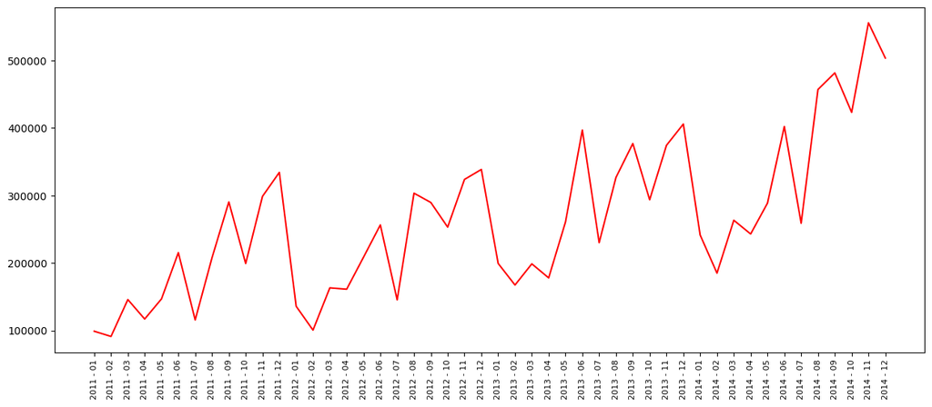

```python
# Visualizing Sales Trends
# Adjusting Figure Size
plt.figure(figsize=(15,6))
# Visualizing Data (Line Graph)
plt.plot(sales_trend['month_year'], sales_trend['sales'], color = 'red')
# Rotating X-Axis Labels
plt.xticks(rotation = 'vertical', size = 8)
# Displaying a Clean Graph
plt.show()
```

Deeper analysis on the sales data reveals a recurring yearly pattern: predictable dips in February and July followed by consistent rebounds and positive growth. This poses an opportunity to utilize this analysis to strategically plan workforce needs, experiment with pricing, and diversify product offerings. Ultimately, leveraging this data empowers this store to navigate and anticipate sales fluctuations to achieve sustainable growth.

```python
# Sales - Day of Week
sales['day_of_week'] = sales['order_date'].dt.weekday
week_sales_trend = (sales.groupby('day_of_week').sum(numeric_only=True)['sales']).reset_index()
week_sales_trend = week_sales_trend.sort_values('sales', ascending=False)

# Renaming Column Names - Easier Readability
week_sales_trend.columns = ['Day', 'Sales']
days = {0: 'Monday', 1: 'Tuesday', 2: 'Wednesday', 3: 'Thursday',
          4: 'Friday', 5: 'Saturday', 6: 'Sunday'}
week_sales_trend['Day'] = week_sales_trend['Day'].map(days)
week_sales_trend
```

|  | Day | Sales |
| --- | --- | --- |
| 4 | Friday | 2.322848e+06 |
| 1 | Tuesday | 2.268417e+06 |
| 3 | Thursday | 2.245837e+06 |
| 0 | Monday | 2.235913e+06 |
| 2 | Wednesday | 2.169218e+06 |
| 5 | Saturday | 1.177964e+06 |
| 6 | Sunday | 2.223045e+05 |

Weekly sales data reveals a distinct trend, which shows Fridays dominating revenue followed by Tuesdays and Thursdays. This suggests targeted weekend promotions and optimized staffing on Fridays and adjacent days could significantly boost revenue and improve customer experience.

- What is the Total Sales Amount Per Region?

```python
# Group data by state and sum sales
sales_by_region = sales.groupby('region')['sales'].sum().reset_index()

# Sort in Ascending Order
sales_by_region = sales_by_region.sort_values('sales' , ascending= False)

# Percentage Per Region
total_sales = sales_by_region["sales"].sum()

# Calculate sales percentage by region
sales_by_region["sales_Percentage"] = sales_by_region["sales"] / total_sales * 100
sales_by_region
```

|  | region | sales | sales_Percentage |
| --- | --- | --- | --- |
| 3 | Central | 2.822303e+06 | 22.323924 |
| 10 | South | 1.600907e+06 | 12.662897 |
| 7 | North | 1.248166e+06 | 9.872774 |
| 9 | Oceania | 1.100185e+06 | 8.702270 |
| 11 | Southeast Asia | 8.844232e+05 | 6.995634 |
| 8 | North Asia | 8.483098e+05 | 6.709983 |
| 5 | EMEA | 8.061613e+05 | 6.376596 |
| 0 | Africa | 7.837732e+05 | 6.199510 |
| 4 | Central Asia | 7.528266e+05 | 5.954728 |
| 12 | West | 7.254578e+05 | 5.738246 |
| 6 | East | 6.787812e+05 | 5.369042 |
| 2 | Caribbean | 3.242809e+05 | 2.565005 |
| 1 | Canada | 6.692817e+04 | 0.529390 |

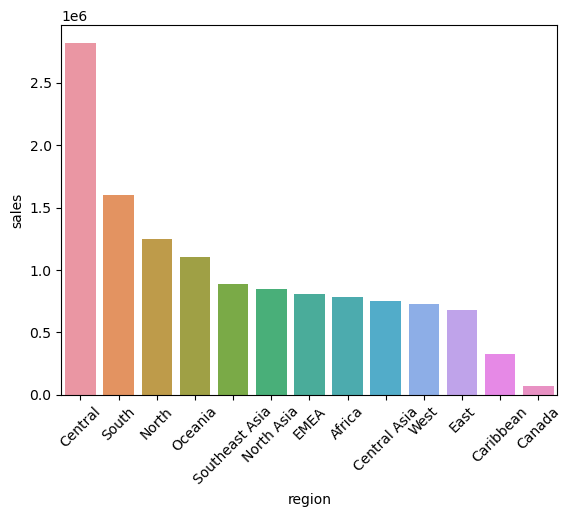

```python
# Visualize Data
sns.barplot(x='region', y='sales', data=sales_by_region)

# Adjust X-Labels
plt.xticks(rotation=45)
plt.show()
```

- Top 10 Products (Sales)

```python
# Grouping Product Name Column and Importing it into a DataFrame
prod_sales = pd.DataFrame(sales.groupby('product_name').sum(numeric_only=True)['sales'])


# Sort DataFramein Ascending Order
prod_sales = prod_sales.sort_values('sales', ascending = False)


# Top 10 Products By Sales
prod_sales[:10]
```

| product_name | sales |
| --- | --- |
| Apple Smart Phone, Full Size | 86935.7786 |
| Cisco Smart Phone, Full Size | 76441.5306 |
| Motorola Smart Phone, Full Size | 73156.3030 |
| Nokia Smart Phone, Full Size | 71904.5555 |
| Canon imageCLASS 2200 Advanced Copier | 61599.8240 |
| Hon Executive Leather Armchair, Adjustable | 58193.4841 |
| Office Star Executive Leather Armchair, Adjustable | 50661.6840 |
| Harbour Creations Executive Leather Armchair, Adjustable | 50121.5160 |
| Samsung Smart Phone, Cordless | 48653.4600 |
| Nokia Smart Phone, with Caller ID | 47877.7857 |

- Top 10 Products (Quantity)

```python
# Grouping By Product Quantity
prod_quant_sold = pd.DataFrame(sales.groupby('product_name').sum(numeric_only=True)['quantity'])

# Sort DataFrame Ascending Order
prod_quant_sold = prod_quant_sold.sort_values('quantity', ascending= False)

# Top 10 Most Sold Products
prod_quant_sold[:10]
```

| product_name | quantity |
| --- | --- |
| Staples | 876 |
| Cardinal Index Tab, Clear | 337 |
| Eldon File Cart, Single Width | 321 |
| Rogers File Cart, Single Width | 262 |
| Sanford Pencil Sharpener, Water Color | 259 |
| Stockwell Paper Clips, Assorted Sizes | 253 |
| Avery Index Tab, Clear | 252 |
| Ibico Index Tab, Clear | 251 |
| Smead File Cart, Single Width | 250 |
| Stanley Pencil Sharpener, Water Color | 242 |

Apple Smartphones lead total sales in revenue generation, while Staples and Clear Index tabs dominate in quantity of items sold. Higher prices contribute significantly to revenue dominance, despite potentially lower sales volume. From the analysis, we can infer that Apple's brand image attracts customers willing to pay more for quality. On the contrary, the staples are essential office supplies often bought in bulk, or regularly replenished, which causes an increased quantity of these items sold. Also, afforable price points make them accessible to a larger customer base, further contributing to their high sale volume.

- What are the most Profitable Categories and Subcategories ?

```python
# Grouping Subcategories with Categories based on Profit
cat_profit = pd.DataFrame(sales.groupby(['category', 'sub_category']).sum(numeric_only=True)['profit'])

# Sort By Cateogry and Profit
cat_profit.sort_values(['category', 'profit'], ascending = False )
```

| category | sub_category | profit |
| --- | --- | --- |
| Technology | Copiers | 258567.54818 |
|  | Phones | 216717.00580 |
|  | Accessories | 129626.30620 |
|  | Machines | 58867.87300 |
| Office Supplies | Appliances | 141680.58940 |
|  | Storage | 108461.48980 |
|  | Binders | 72449.84600 |
|  | Paper | 59207.68270 |
|  | Art | 57953.91090 |
|  | Envelopes | 29601.11630 |
|  | Supplies | 22583.26310 |
|  | Labels | 15010.51200 |
|  | Fasteners | 11525.42410 |
| Furniture | Bookcases | 161924.41950 |
|  | Chairs | 141973.79750 |
|  | Furnishings | 46967.42550 |
|  | Tables | -64083.38870 |

Our data reveals a contrast between high-performing technology products and furniture, particularly tables. While technology drives total profits, tables represent a significant loss, accounting for a $64,083.40 loss. Additional analysis behind the cause of the 64,083.40 loss of tabel profits will be needed to improve sales and boost overall store performance.

- What is the Preferred Shippign Method ?

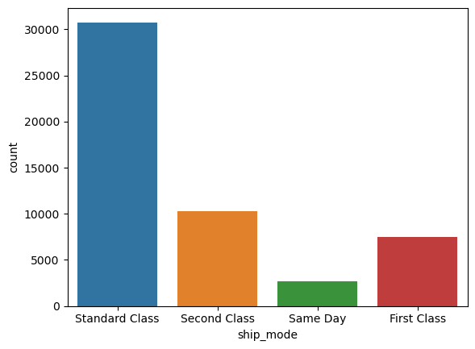

```python
# Visualizing Popular Shipping Methods

sns.countplot(x = 'ship_mode' , data = sales)
```

Data reveals a clear preference for Standard Class shipping , while Same Day shipping is the least preferred method. This could be attributed to pricing associated with these options, as Standard Class shipping methods are more cost effective compared to Same Day shipping methods. This presents a strategic opportunity to leverage incentives and explore diverse delivery options, which could potentially increase sales without major resource investment.